# Momentum in the S&P 500

A Quintile Analysis, 1993–2025

Author

Jack Simmons

Published

March 14, 2026

## Introduction

Price momentum — the tendency for assets that have performed well recently to continue outperforming — is one of the most replicated findings in empirical finance. Jegadeesh and Titman (1993) documented it in U.S. equities; it has since been found across asset classes and geographies.

This analysis examines momentum at the **index level** using the S&P 500 (proxied by SPY from its 1993 inception). Rather than asking whether a momentum *strategy* beats buy-and-hold — an unfair contest during a 30-year bull market — we ask a more precise question:

> *Within the distribution of monthly momentum signals observed since 1993, do months with high signals predict meaningfully higher forward returns than months with low signals?*

The framework is quintile analysis: for each metric, we bin all monthly observations into five equal groups and measure mean forward returns per group. The Q5–Q1 spread is our primary measure of signal efficacy.

## Data

SPY adjusted-close daily prices from January 1993 to present, sourced via `yfinance`. Adjusted close accounts for dividends and splits, approximating a total return series.

```python
import sys
import os
sys.path.insert(0, os.path.dirname(os.path.abspath("momentum_analysis.qmd")))

import pandas as pd
import numpy as np
import matplotlib
matplotlib.use("Agg")
import matplotlib.pyplot as plt
import seaborn as sns
from IPython.display import Image, display

from fetch_data import fetch
from momentum import compute_all
from analytics import (
    align_monthly, forward_returns,
    spread_stat, information_coefficient,
    multi_signal_tranche,
)
from backtest import (
    spread_table, quintile_analysis,
    plot_quintile_bars, plot_spread_heatmap,
    plot_tranche_heatmap, plot_rolling_spread,
)

prices_df = fetch()
prices = prices_df["price"].squeeze()
metrics = compute_all(prices)
fwd = forward_returns(prices)

print(f"Daily observations : {len(prices):,}")
print(f"Date range         : {prices.index[0].date()} to {prices.index[-1].date()}")
print(f"Monthly obs (fwd)  : {len(fwd):,}")
```

```
Downloading SPY from 1993-01-01...
Saved 8337 rows to data\spy_daily.csv
Daily observations : 8,337
Date range         : 1993-01-29 to 2026-03-13
Monthly obs (fwd)  : 387
```

## Momentum Metrics

Eight metrics are computed from the daily price series. They fall into three families:

| Metric | Formula | Intuition |
| --- | --- | --- |
| `mom_12_1` | Return(t–12m → t–1m) | Classic Jegadeesh-Titman: 12-month momentum skipping the most recent month to avoid short-term reversal |
| `mom_6_1` | Return(t–6m → t–1m) | Shorter lookback; more responsive to recent trends |
| `mom_3_1` | Return(t–3m → t–1m) | Short-term momentum |
| `mom_1` | Return(t–1m → t) | Raw 1-month return; often reverses |
| `ma_ratio` | Price / 200-day MA – 1 | Trend-following: distance above/below long-run average |
| `high_52w` | Price / 52-week high – 0.95 | Proximity to annual high; >0 means within 5% |
| `risk_adj` | mom_12_1 / realised vol | Volatility-adjusted momentum (Sharpe-like) |
| `tsmom` | sign(mom_12_1) | Binary: +1 (positive trend) or –1 (negative) |

```python
print("Metrics computed:", list(metrics.columns))
print(f"\nSample (last 5 rows):")
print(metrics.tail().round(4).to_string())
```

```
Metrics computed: ['mom_12_1', 'mom_6_1', 'mom_3_1', 'mom_1', 'ma_ratio', 'high_52w', 'risk_adj', 'tsmom']

Sample (last 5 rows):
            mom_12_1  mom_6_1  mom_3_1   mom_1  ma_ratio  high_52w  risk_adj  tsmom
date
2026-03-09    0.1971   0.0529  -0.0070  0.0010    0.0362    0.0252    1.0313    1.0
2026-03-10    0.2132   0.0705   0.0102 -0.0195    0.0337    0.0237    1.1162    1.0
2026-03-11    0.2525   0.0732   0.0181 -0.0254    0.0317    0.0225    1.3352    1.0
2026-03-12    0.2596   0.0673   0.0163 -0.0377    0.0153    0.0077    1.3698    1.0
2026-03-13    0.2527   0.0582   0.0094 -0.0429    0.0090    0.0023    1.3328    1.0
```

## Analytical Framework

For each metric and each forward return horizon (1m, 3m, 6m, 12m):

1. **Align**: Resample the signal to month-end. Lag by one month so the signal is observable *before* the forward return period begins — no look-ahead bias.
2. **Bin**: Divide the full sample into quintiles (Q1 = lowest signal, Q5 = highest).
3. **Measure**: Compute mean forward return within each quintile.
4. **Summarise**: Report the Q5–Q1 spread as a scalar measure of predictive power.

`tsmom` is excluded from quintile analysis (only two unique values; cannot form five bins). It is assessed via hit rate instead.

## Full-Period Results

### Q5–Q1 Spread Heatmap

The heatmap below shows the Q5–Q1 spread (%) across all metrics and forward horizons over the full 1993–2025 sample. Green = higher-signal months predicted higher returns; red = the opposite.

```
Chart saved to data/spread_heatmap.png
```

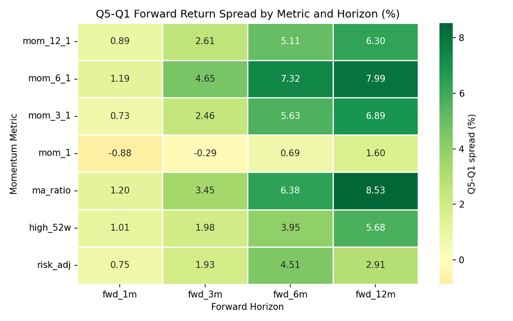

```python
spreads = spread_table(prices, metrics)
plot_spread_heatmap(spreads)
display(Image("data/spread_heatmap.png"))
```

**Key observations:**

- `mom_6_1` and `ma_ratio` show the strongest and most consistent positive spreads, particularly at 3m and 6m horizons.
- `mom_1` is negative at short horizons — a textbook short-term reversal effect.
- `high_52w` and `risk_adj` show modest spreads; the former is noisy, the latter largely redundant with `mom_12_1`.

### Quintile Return Profiles (3-Month Horizon)

The bar charts below show the full distribution — mean return for each quintile, not just the top and bottom — at the 3-month forward horizon.

```
Chart saved to data/quintiles_fwd_3m.png
```

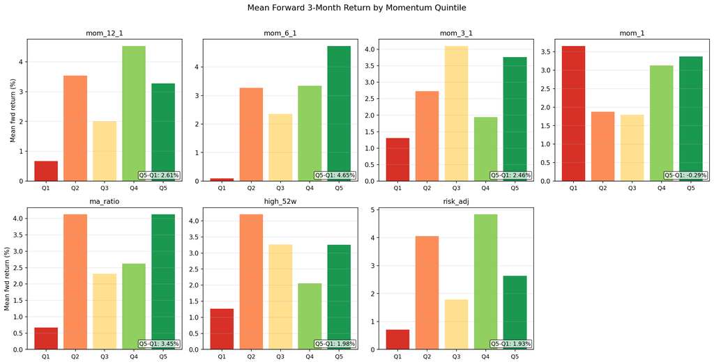

```python
plot_quintile_bars(prices, metrics, horizon="fwd_3m")
display(Image("data/quintiles_fwd_3m.png"))
```

## Time Dependency

A positive full-period spread can mask substantial regime variation. A signal that worked strongly in one era and failed in another is less reliable than one that is consistently positive. We examine this two ways.

### 5-Year Tranche Heatmap

Each cell is the Q5–Q1 spread within that 5-year window, using 20th/80th percentile cutoffs. With ~60 monthly observations per cell, estimates are more stable than year-by-year.

```
Chart saved to data/tranche_heatmap_fwd_3m_5y.png
```

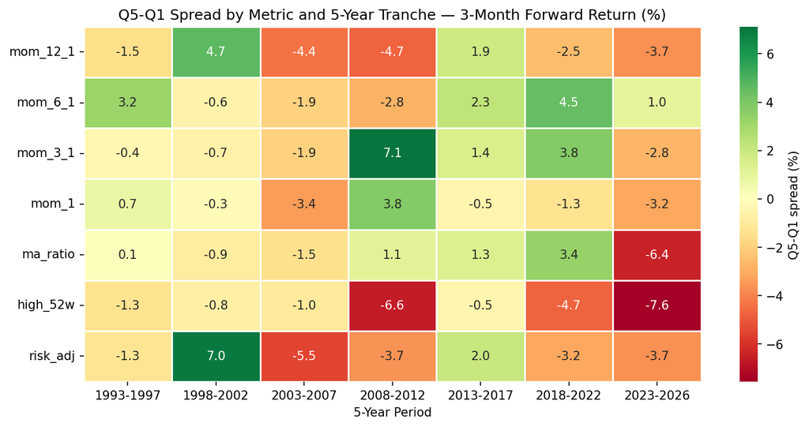

```python
plot_tranche_heatmap(prices, metrics, horizon="fwd_3m", tranche_years=5)
display(Image("data/tranche_heatmap_fwd_3m_5y.png"))
```

**Key observations:**

- No metric is green across all tranches — regime dependence is universal.
- `mom_6_1` is the most consistent: positive in 4 of 7 tranches, and the trend since 2013 is notably green.
- The 2003–2012 period was broadly hostile to momentum at the index level, likely reflecting the two major bear-market reversals (dot-com, GFC).
- `high_52w` is structurally weak — negative or near-zero in most periods.

### Rolling 36-Month Information Coefficient

The IC (Spearman rank correlation between signal and forward return) computed over a rolling 36-month window shows how signal quality evolves continuously over time.

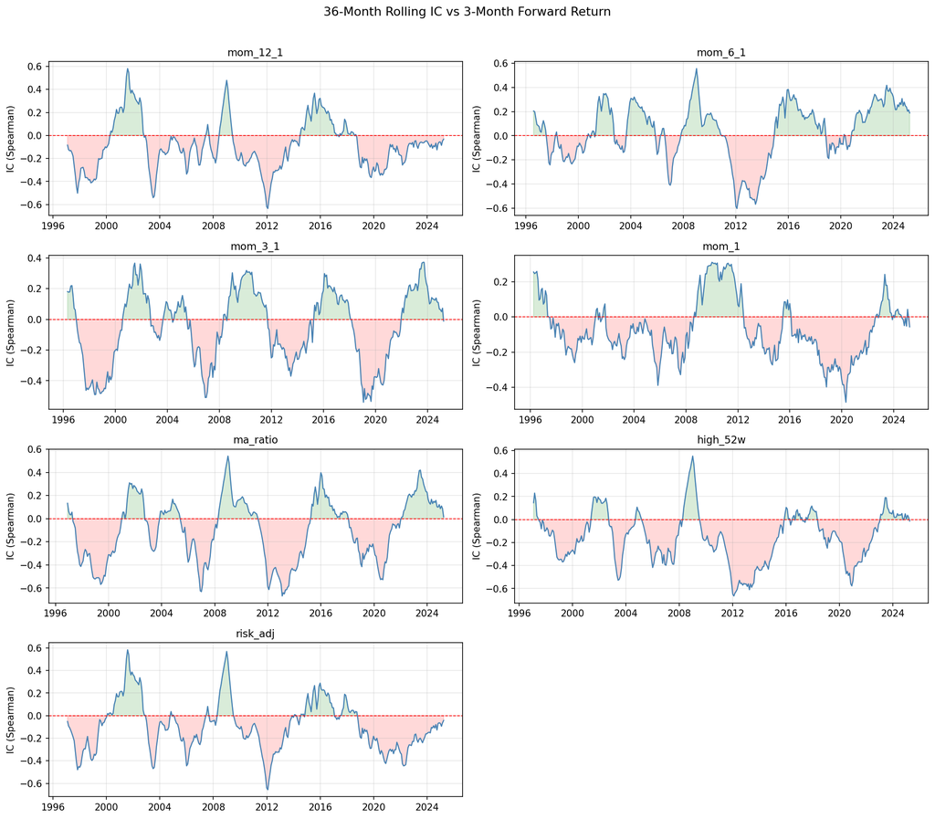

```python
# Compute rolling IC for each metric vs 3m forward return
outcome = fwd["fwd_3m"]
fig, axes = plt.subplots(4, 2, figsize=(14, 12), sharey=False)
axes = axes.flatten()

from analytics import rolling_eval

cols = [c for c in metrics.columns if c != "tsmom"]
for i, col in enumerate(cols):
    aligned = align_monthly(metrics[col], outcome, lag=1)
    rolling_ic = rolling_eval(
        aligned["signal"], aligned["outcome"],
        information_coefficient, window=36
    )
    ax = axes[i]
    s = rolling_ic.dropna()
    ax.plot(s.index, s.values, color="steelblue", linewidth=1.2)
    ax.axhline(0, color="red", linewidth=0.8, linestyle="--")
    ax.fill_between(s.index, s.values, 0, where=s.values > 0, alpha=0.15, color="green")
    ax.fill_between(s.index, s.values, 0, where=s.values < 0, alpha=0.15, color="red")
    ax.set_title(col, fontsize=11)
    ax.set_ylabel("IC (Spearman)")
    ax.grid(alpha=0.3)

for j in range(i + 1, len(axes)):
    axes[j].set_visible(False)

fig.suptitle("36-Month Rolling IC vs 3-Month Forward Return", fontsize=13, y=1.01)
plt.tight_layout()
plt.savefig("data/rolling_ic_3m.png", dpi=150, bbox_inches="tight")
plt.close()
display(Image("data/rolling_ic_3m.png"))
```

The rolling IC reveals what the tranche heatmap compresses: `mom_6_1` has been positively correlated with 3-month forward returns for most of the post-2013 period, with IC values persistently in the 0.1–0.3 range — economically meaningful for a single-factor signal.

## Summary Statistics

```python
rows = []
for col in [c for c in metrics.columns if c != "tsmom"]:
    aligned = align_monthly(metrics[col], outcome, lag=1)
    s  = spread_stat(aligned["signal"], aligned["outcome"]) * 100
    ic = information_coefficient(aligned["signal"], aligned["outcome"])
    rows.append({"Metric": col, "Spread (%, 3m)": round(s, 2), "IC (Spearman)": round(ic, 3)})

summary = pd.DataFrame(rows).set_index("Metric").sort_values("IC (Spearman)", ascending=False)
print(summary.to_string())
```

[output not shown]

## Conclusions

**1. `mom_6_1` is the most robust momentum signal at the index level.** A 6-month lookback (skipping the most recent month) produces the highest IC and the most consistent Q5–Q1 spread across 5-year tranches. The signal has strengthened since 2013, not weakened — counter to common assumptions about momentum decay.

**3. No signal is regime-stable.** Every metric spent extended periods (2003–2012 in particular) with near-zero or negative spreads. This argues against using any single momentum metric as a standalone timing rule, and in favour of treating them as probabilistic inputs to a broader framework.

*Analysis produced using SPY adjusted-close data via yfinance. All forward returns computed on a look-ahead-free basis with a one-month signal lag. Code available at github.com/jackmdsimmons/sp500-momentum.*